# Lista 2

Carmen Maria

23/03/2026

## Exercícios Lista 2: RMarkdown

*Os exercícios que se referem a aula 2 foram feitos no RStudios e as respostas registradas no google docs que envio em anexo também. Peço perdão por não condensar todos juntos fiquei com honesto medo de não conseguir enviar dessa maneira.*

No arquivo .Rmd criado, adicione: (a) um parágrafo com texto em negrito e itálico; (b) uma lista numerada; (c) um chunk de código R que calcule a média de um vetor qualquer. Renderize o documento.

*Adicionando um parágrafo com texto em itálico e em negrito esperançosamente dando certo!!*

1. Em sequência
2. Vamos adicionar uma lista numerada
3. No próximo espaço espero conseguir adicionar o chunk com média aritmética de um vetor qualquer

```r
mean(c(1, 2, 3, 4, 5))
```

```
## [1] 3
```

Crie um documento R Markdown que importe o banco dados/pib_cid.RDS, apresente uma tabela com as 10 primeiras linhas (usando kable()) e um gráfico de sua escolha. Use a opção echo = FALSE nos chunks para esconder o código no documento final.

Tabela com as 10 primeiras linhas

| ano | codigo_regiao | nome_regiao | codigo_uf | sigla_uf | nome_uf | cod_municipio | nome_munic | nome_metro | codigo_meso | nome_meso | codigo_micro | nome_micro | codigo_reg_geo_imediata | nome_reg_geo_imediata | mun_reg_geo_imediata | codigo_reg_geo_intermediaria | nome_reg_geo_intermediaria | mun_reg_geo_intermediaria | codigo_concentracao_urbana | nome_concentracao_urbana | tipo_concentracao_urbana | codigo_arranjo_populacional | nome_arranjo_populacional | hierarquia_urbana | hierarquia_urbana_principais | codigo_regiao_rural | nome_regiao_rural | regiao_rural_classificacao | amazonia_legal | … |
| --- | --- | --- | --- | --- | --- | --- | --- | --- | --- | --- | --- | --- | --- | --- | --- | --- | --- | --- | --- | --- | --- | --- | --- | --- | --- | --- | --- | --- | --- | --- |
| 2013 | 1 | Norte | 11 | RO | Rondônia | 1100015 | Alta Floresta D’Oeste | NA | 1102 | Leste Rondoniense | 11006 | Cacoal | 110005 | Cacoal | do Entorno | 1102 | Ji-Paraná | do Entorno | NA | NA | NA | NA | NA | Centro Local | Centro Local | 1101 | Região Rural da Capital Regional de Porto Velho | Região Rural de Capital Regional | Sim | … |
| 2013 | 1 | Norte | 11 | RO | Rondônia | 1100023 | Ariquemes | NA | 1102 | Leste Rondoniense | 11003 | Ariquemes | 110002 | Ariquemes | Polo | 1101 | Porto Velho | do Entorno | NA | NA | NA | NA | NA | Centro Sub-regional B | Centro Sub-regional | 1101 | Região Rural da Capital Regional de Porto Velho | Região Rural de Capital Regional | Sim | … |
| 2013 | 1 | Norte | 11 | RO | Rondônia | 1100031 | Cabixi | NA | 1102 | Leste Rondoniense | 11008 | Colorado do Oeste | 110006 | Vilhena | do Entorno | 1102 | Ji-Paraná | do Entorno | NA | NA | NA | NA | NA | Centro Local | Centro Local | 1101 | Região Rural da Capital Regional de Porto Velho | Região Rural de Capital Regional | Sim | … |
| 2013 | 1 | Norte | 11 | RO | Rondônia | 1100049 | Cacoal | NA | 1102 | Leste Rondoniense | 11006 | Cacoal | 110005 | Cacoal | Polo | 1102 | Ji-Paraná | do Entorno | NA | NA | NA | NA | NA | Centro Sub-regional B | Centro Sub-regional | 5105 | Região Rural do Centro Sub-regional de Vilhena (RO) e Cacoal (RO) | Região Rural de Centro Sub-regional | Sim | … |
| 2013 | 1 | Norte | 11 | RO | Rondônia | 1100056 | Cerejeiras | NA | 1102 | Leste Rondoniense | 11008 | Colorado do Oeste | 110006 | Vilhena | do Entorno | 1102 | Ji-Paraná | do Entorno | NA | NA | NA | NA | NA | Centro de Zona B | Centro de Zona | 1101 | Região Rural da Capital Regional de Porto Velho | Região Rural de Capital Regional | Sim | … |
| 2013 | 1 | Norte | 11 | RO | Rondônia | 1100064 | Colorado do Oeste | NA | 1102 | Leste Rondoniense | 11008 | Colorado do Oeste | 110006 | Vilhena | do Entorno | 1102 | Ji-Paraná | do Entorno | NA | NA | NA | NA | NA | Centro Local | Centro Local | 1101 | Região Rural da Capital Regional de Porto Velho | Região Rural de Capital Regional | Sim | … |
| 2013 | 1 | Norte | 11 | RO | Rondônia | 1100072 | Corumbiara | NA | 1102 | Leste Rondoniense | 11008 | Colorado do Oeste | 110006 | Vilhena | do Entorno | 1102 | Ji-Paraná | do Entorno | NA | NA | NA | NA | NA | Centro Local | Centro Local | 1101 | Região Rural da Capital Regional de Porto Velho | Região Rural de Capital Regional | Sim | … |
| 2013 | 1 | Norte | 11 | RO | Rondônia | 1100080 | Costa Marques | NA | 1101 | Madeira-Guaporé | 11002 | Guajará-Mirim | 110004 | Ji-Paraná | do Entorno | 1102 | Ji-Paraná | do Entorno | NA | NA | NA | NA | NA | Centro Local | Centro Local | 1101 | Região Rural da Capital Regional de Porto Velho | Região Rural de Capital Regional | Sim | … |
| 2013 | 1 | Norte | 11 | RO | Rondônia | 1100098 | Espigão D’Oeste | NA | 1102 | Leste Rondoniense | 11006 | Cacoal | 110005 | Cacoal | do Entorno | 1102 | Ji-Paraná | do Entorno | NA | NA | NA | NA | NA | Centro Local | Centro Local | 5105 | Região Rural do Centro Sub-regional de Vilhena (RO) e Cacoal (RO) | Região Rural de Centro Sub-regional | Sim | … |
| 2013 | 1 | Norte | 11 | RO | Rondônia | 1100106 | Guajará-Mirim | NA | 1101 | Madeira-Guaporé | 11002 | Guajará-Mirim | 110001 | Porto Velho | do Entorno | 1101 | Porto Velho | do Entorno | NA | NA | NA | 1100106 | Internacional de Guajará-Mirim/Brasil - Guayaramerín/Bolívia | Centro de Zona B | Centro de Zona | 1101 | Região Rural da Capital Regional de Porto Velho | Região Rural de Capital Regional | Sim | … |

Gráfico histograma com pib_per_capita e pintado a partir das cores por região

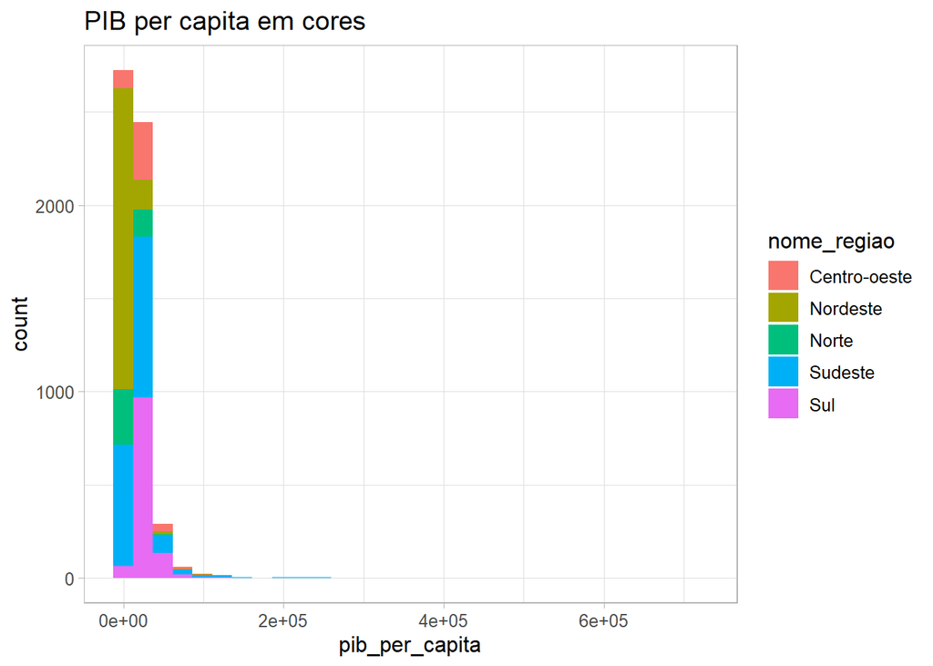

*Na tabela e no gráfico escondi também os avisos e as mensagens*

Crie a estrutura de pastas de um projeto de pesquisa seguindo a convenção apresentada neste capítulo (data/raw/, data/processed/, scripts/, outputs/, paper/). Dentro de scripts/, crie dois arquivos vazios: 01_clean.R e 02_analysis.R. Inicialize o projeto como repositório Git e faça o primeiro commit.

Fazendo no Git! Fica aqui o link do Git que estão os repositórios [GIT](https://github.com/carmenmarias/exercicio-stat-basica/tree/main)